# Life Science and Device Intel

**Week of August 31, 2026**Market data through: August 28, 2026Narrative created: August 31, 2026

Weekly review of pharmaceutical, biotech, biologics, and medical-device company performance, changes, earnings activity, and strategy narrative.

## In the News

### Executive View

- **Last week’s personalized-cancer-vaccine breakthrough now has an important boundary condition.** BioNTech and Genentech terminated an individualized mRNA vaccine trial in colorectal cancer after futility and an overall-survival imbalance, indicating that melanoma success cannot be generalized across tumors or to vaccine monotherapy.
- **Direct RAS inhibition delivered an unusually large survival advance in pancreatic cancer.** FDA approved Revolution Medicines’ daraxonrasib after median overall survival reached 13.2 months versus 6.7 months with chemotherapy.
- **Dermatomyositis became an active competitive market almost overnight.** FDA approved Priovant’s oral brepocitinib one week after Argenx reported positive Phase 3 Vyvgart data, creating an emerging contest between oral convenience and FcRn-mediated IgG reduction.
- **HER2-positive upper-GI treatment gained a powerful new regimen, but not a definitive winner.** Zanidatamab plus tislelizumab and chemotherapy extended median survival by 7.2 months, although the trial did not compare against a checkpoint-containing trastuzumab regimen.
- **Ivonescimab’s efficacy thesis expanded beyond lung cancer.** The PD-1/VEGF bispecific beat durvalumab plus chemotherapy on overall survival in first-line biliary-tract cancer, albeit without disclosed effect sizes.
- **Hepcidin mimetics reached commercial validation.** Takeda’s rusfertide substantially reduced phlebotomy requirements in polycythemia vera, shifting treatment toward direct control of iron availability.
- **Capital is converging on selective removal of pathogenic antibodies.** Lilly agreed to acquire Merida for up to $2.875 billion, while Biohaven monetized its epilepsy platform to SK Biopharmaceuticals ahead of a pivotal readout—potentially helping finance its competing extracellular-degrader strategy.

### Strategy Narrative

#### Personalized mRNA vaccines remain validated—but are no longer a single thesis

**What changed.** On August 28, BioNTech terminated the randomized Phase 2 BNT122-01 trial of autogene cevumeran as adjuvant monotherapy in ctDNA-positive, resected colorectal cancer. The futility boundary had been crossed in October 2025; the latest monitoring review also identified a numerical overall-survival imbalance and concluded that continued treatment was unlikely to change the efficacy outcome. The monitoring board identified no new product-level safety signal. ([sec.gov](https://www.sec.gov/Archives/edgar/data/1776985/000177698526000061/a991260828_bntxxcrcxenxfin.htm?utm_source=openai))

**Why it matters.** This directly qualifies last Monday’s conclusion following Moderna and Merck’s Phase 3 melanoma success. Individualized manufacturing and neoantigen selection have been validated at pivotal scale, but efficacy appears dependent on tumor immunogenicity, disease context and combination strategy. The successful melanoma regimen included Keytruda; the failed colorectal trial tested vaccine monotherapy against observation.

**What it tells us.** The modality should be valued as a potentially powerful component of immune combinations—not as a broadly effective standalone platform. ctDNA enrichment identified patients at high risk, but molecular residual disease did not guarantee that vaccination alone could generate adequate tumor control.

**What to watch next.** Detailed survival and recurrence data, and BioNTech’s continuing studies combining autogene cevumeran with checkpoint blockade.

#### Pancreatic cancer becomes the first major commercial test of multi-RAS inhibition

**What changed.** FDA approved Revolution Medicines’ once-daily **Rasonque (daraxonrasib)** on August 26 for previously treated metastatic pancreatic adenocarcinoma or patients unable to receive multiagent therapy. In a 500-patient randomized trial, median overall survival was 13.2 months versus 6.7 months with standard chemotherapy. FDA completed the review 6.5 months before the user-fee deadline through its Commissioner’s National Priority Voucher pilot. ([fda.gov](https://www.fda.gov/news-events/press-announcements/fda-approves-first-class-targeted-therapy-metastatic-pancreatic-cancer))

**Why it matters.** The absolute survival difference is exceptional for second-line pancreatic cancer and transforms direct RAS inhibition from a mutation-specific niche into a potentially broad pancreatic franchise. Unlike KRAS G12C inhibitors, daraxonrasib targets multiple RAS forms and therefore addresses much more of the disease.

**What it tells us.** RAS may finally be becoming a repeatable therapeutic class rather than a sequence of narrowly defined mutation programs. Commercially, the broad label and oral administration are meaningful; scientifically, durability, mutation-level outcomes and resistance mechanisms remain essential.

**What to watch next.** Hazard ratios and subgroup data, uptake across KRAS genotypes, movement into first-line combinations and whether the priority-voucher pathway produces similarly compressed reviews for other products.

#### Dermatomyositis shifts from therapeutic scarcity to modality competition

FDA approved **Lisraya (brepocitinib)** on August 27 as the first oral treatment for adult dermatomyositis. The 241-patient Phase 3 trial showed greater improvement on the composite Total Improvement Score, physical function and skin disease, with more patients reducing corticosteroids. The once-daily TYK2/JAK1 inhibitor carries the class boxed warning for serious infection, malignancy, cardiovascular events, thrombosis and mortality. ([fda.gov](https://www.fda.gov/news-events/press-announcements/fda-approves-first-oral-drug-indicated-treat-dermatomyositis-adults))

That materially changes the interpretation of last week’s positive Vyvgart result. Argenx is no longer developing for an empty market: it may have to differentiate FcRn blockade against an immediately available pill. Lisraya has the convenience advantage; Vyvgart could compete through a different safety profile, rapid IgG-directed biology and evidence generated during protocol-mandated steroid tapering.

The likely market is therefore not winner-take-all. Treatment may segment by disease severity, comorbidity, JAK-warning tolerance and physician preference. The next important evidence is detailed cross-study comparison of TIS components, steroid exposure, infections and durability—while recognizing that only a direct trial can establish comparative efficacy.

#### Two first-line oncology results increase pressure on incumbent checkpoint regimens

FDA approved **Ziihera (zanidatamab)** with tislelizumab and chemotherapy for HER2-positive advanced gastric, gastroesophageal-junction and esophageal adenocarcinoma. Median overall survival was 26.4 months versus 19.2 months with trastuzumab plus chemotherapy; median progression-free survival was 12.4 versus 8.1 months. Zanidatamab plus chemotherapy without tislelizumab received a narrower IHC3+ label because benefit in the lower-HER2-expression population appeared limited. ([fda.gov](https://www.fda.gov/drugs/resources-information-approved-drugs/fda-approves-zanidatamab-hrii-and-tislelizumab-jsgr-her2-positive-gastric-gastroesophageal-junction))

The magnitude is clinically meaningful and validates zanidatamab’s biparatopic HER2 design in first line. However, the comparator lacked checkpoint inhibition, leaving unresolved how the regimen performs against pembrolizumab-containing HER2 treatment. The label’s separation by HER2 intensity also reinforces that “HER2-positive” is not a biologically uniform commercial segment.

Separately, Akeso reported that **ivonescimab plus chemotherapy beat durvalumab plus chemotherapy on overall survival**, while also meeting PFS and response endpoints, in first-line advanced biliary-tract cancer. Effect sizes remain undisclosed. ([akesobio.com](https://akesobio.com/en/media/akeso-news/260826/?utm_source=openai))

This is strategically important because it extends the PD-1/VEGF bispecific thesis beyond lung cancer and defeats an active immunotherapy standard rather than chemotherapy alone. Confirmation requires detailed safety, geographic representation and survival data.

#### Rusfertide converts phlebotomy reduction into an approved treatment paradigm

FDA approved Takeda’s **Mimrylo (rusfertide)** on August 28 for erythrocytosis in adults with polycythemia vera. In the 293-patient VERIFY trial, 76.9% of patients met the phlebotomy-control endpoint versus 32.9% on placebo. The weekly hepcidin mimetic limits iron availability for red-blood-cell production; common adverse reactions included injection-site reactions and anemia. ([fda.gov](https://www.fda.gov/news-events/press-announcements/fda-approves-first-drug-its-kind-polycythemia-vera-rare-blood-disorder))

The commercial value comes from reducing a recurring care burden while addressing the biological machinery driving hematocrit elevation. The scientific caveat is equally important: maintaining hematocrit and avoiding phlebotomy does not yet prove fewer thrombotic events or longer survival. Real-world adoption will depend on whether convenience and symptom improvements justify chronic injections and monitoring.

### Transactions, Technology & Operational Risk

Lilly’s August 31 agreement to acquire **Merida Biosciences for up to $2.875 billion** validates selective degradation of pathogenic antibodies as an emerging immunology modality. Lead asset MER511 is only in Phase 1 for Graves’ disease and thyroid-eye disease, and the upfront payment was not disclosed, so the headline value should not be mistaken for a clinically de-risked valuation. Nevertheless, the transaction creates direct strategic competition for Biohaven’s extracellular protein-degrader platform. ([investor.lilly.com](https://investor.lilly.com/node/54871/pdf))

Biohaven simultaneously licensed worldwide rights to its pivotal-stage Kv7 epilepsy platform, including opakalim, to SK Biopharmaceuticals for $400 million in near-term payments and up to $795 million overall, plus royalties. The deal transfers substantial development and commercialization risk before the RISE3 readout while preserving capital for Biohaven’s broader pipeline. ([sec.gov](https://www.sec.gov/Archives/edgar/data/1935979/000193597926000072/bhvn-20260826.htm?utm_source=openai))

In devices, FDA authorized Abbott’s **Libre Duo**, the first wearable continuously monitoring both glucose and ketones. Clinical validation established analytical detection of elevated ketones before diabetic ketoacidosis, but commercial and payer value will ultimately depend on demonstrating fewer emergency events. ([fda.gov](https://www.fda.gov/news-events/press-announcements/fda-authorizes-first-wearable-device-continuously-monitors-both-ketone-levels-and-blood-sugar))

Among the supplied watchlist movers, only Boston Scientific had a consequential new development. A cybersecurity incident caused global operational disruption, constrained order processing and shipping, and interrupted pairing of some insertable cardiac monitors with remote-monitoring applications. The episode illustrates that cybersecurity in connected medtech is now simultaneously a patient-workflow, supply-chain and revenue-continuity risk. ([sec.gov](https://www.sec.gov/Archives/edgar/data/885725/000088572526000056/bsx-20260826.htm?utm_source=openai))

### What I’m Watching Next

- Detailed INTerpath-001 melanoma and BNT122 colorectal data defining where personalized vaccines work.
- Daraxonrasib outcomes by RAS genotype and plans for first-line pancreatic cancer.
- Regulatory timing and positioning of Vyvgart versus approved Lisraya in dermatomyositis.
- Full ivonescimab biliary-tract survival and safety results.
- Restoration of Boston Scientific’s ordering and remote-monitoring systems.

### Bottom Line

This week replaced several broad modality narratives with more discriminating ones. Personalized mRNA vaccination works in at least one pivotal combination setting but failed as monotherapy in molecularly residual colorectal cancer. RAS inhibition produced a major pancreatic-cancer survival advance, while bispecific antibodies improved first-line outcomes in two gastrointestinal cancers. In immunology, oral JAK inhibition, FcRn blockade and selective autoantibody degradation are converging on the same diseases.

The strategic premium is increasingly accruing not simply to novel mechanisms, but to mechanisms that demonstrate where, with what combination and in which biologically selected patients they can deliver meaningful benefit.

## Notable Changes

Comparison with the final report dated August 24, 2026 (market data through August 21, 2026).

### Sectors

#### Top-three comparison

| Entity | Previous | Current | Change | Current return |
| --- | --- | --- | --- | --- |
| Emerging Biotech | #1 | #1 | — 0 | +69.6% |
| Established Biotech | #2 | #2 | — 0 | +50.1% |
| Big Pharma | #3 | #3 | — 0 | +38.7% |

### Stocks

#### Top-three comparison

| Entity | Previous | Current | Change | Current return |
| --- | --- | --- | --- | --- |
| Moderna (MRNA) | #1 | #1 | — 0 | +472.8% |
| CG Oncology (CGON) | #2 | #2 | — 0 | +177.2% |
| Krystal Biotech (KRYS) | #3 | #3 | — 0 | +138.0% |

#### Largest rank changes

| Entity | Previous | Current | Change | Current return |
| --- | --- | --- | --- | --- |
| Novocure (NVCR) | #21 | #15 | ↑ 6 | +44.5% |
| Argenx (ARGX) | #9 | #16 | ↓ 7 | +43.7% |
| Sarepta (SRPT) | #38 | #28 | ↑ 10 | +14.6% |

### Subcategory movement since the previous report

| Subcategory | Move | Last Report, 12m Ret | Current Report, 12m Ret |
| --- | --- | --- | --- |
| Established Biotech | -1.3% | +49.3% | +50.1% |
| Devices & Diagnostic | -2.1% | -13.1% | -13.7% |
| Big Pharma | -3.3% | +43.8% | +38.7% |
| Emerging Biotech | -4.2% | +78.0% | +69.6% |

### Largest company moves

| Direction | Company | Ticker | Move |
| --- | --- | --- | --- |
| Gain | Sarepta | SRPT | +11.0% |
| Gain | Novocure | NVCR | +4.2% |
| Gain | ResMed | RMD | +3.8% |
| Decline | Boston Scientific | BSX | -7.0% |
| Decline | CG Oncology | CGON | -6.9% |
| Decline | Corcept Therapeutics | CORT | -6.8% |

## Subcategory Performance

| Subcategory | Companies | Market cap | 3m Return | 12m Return | 24m Return |
| --- | --- | --- | --- | --- | --- |
| Devices & Diagnostic | 17 | $839.9B | +12.8% | -13.7% | -7.0% |
| Big Pharma | 12 | $3.6T | +9.6% | +38.7% | +21.8% |
| Established Biotech | 15 | $813.7B | +22.2% | +50.1% | +37.6% |
| Emerging Biotech | 10 | $56.3B | +26.4% | +69.6% | +124.9% |

Subcategory returns use the most recently saved market capitalizations as weights.

## Stock Performance vs. SPY

The same selected stocks appear in every chart. Each line is labeled at the right with its ticker and return for the displayed window.

### Last 6 months

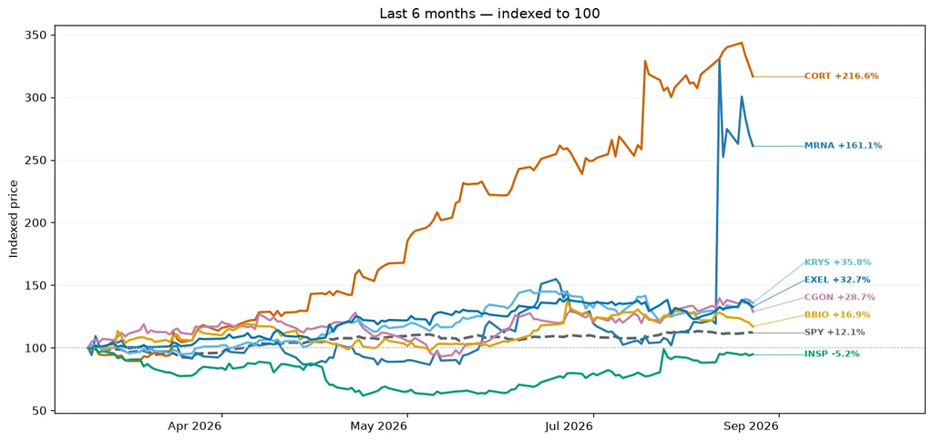

### Last 12 months

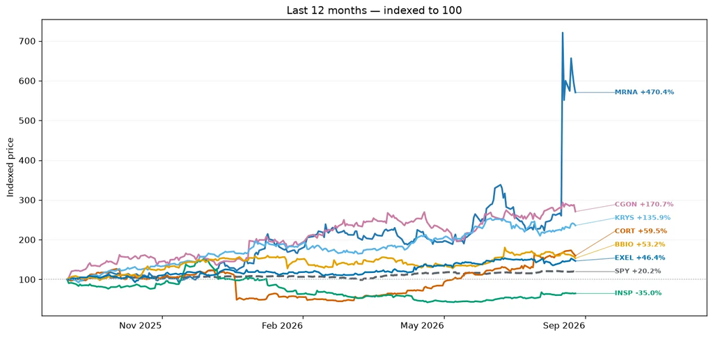

### Last 24 months

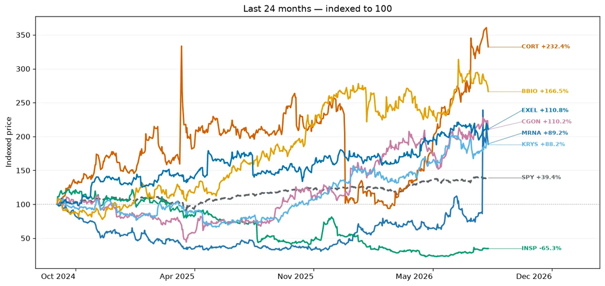

## Current Top Stocks

### Last 3 months

| Rank | Company | Ticker | Market cap | Return |
| --- | --- | --- | --- | --- |
| 1 | Moderna | MRNA | $22.8B | +192.4% |
| 2 | Corcept Therapeutics | CORT | $11.9B | +63.9% |
| 3 | Inspire Medical Systems | INSP | $1.9B | +48.5% |
| 4 | Acadia Pharmaceuticals | ACAD | $4.6B | +34.4% |
| 5 | Transmedics | TMDX | $2.8B | +31.6% |

### Last 12 months

| Rank | Company | Ticker | Market cap | Return |
| --- | --- | --- | --- | --- |
| 1 | Moderna | MRNA | $22.8B | +472.8% |
| 2 | CG Oncology | CGON | $6.3B | +177.2% |
| 3 | Krystal Biotech | KRYS | $9.6B | +138.0% |
| 4 | Merck | MRK | $316.1B | +76.4% |
| 5 | United Therapeutics | UTHR | $22.0B | +69.1% |

### Last 24 months

| Rank | Company | Ticker | Market cap | Return |
| --- | --- | --- | --- | --- |
| 1 | Corcept Therapeutics | CORT | $11.9B | +222.6% |
| 2 | BridgeBio Pharma | BBIO | $16.1B | +175.0% |
| 3 | Exelixis | EXEL | $14.1B | +109.2% |
| 4 | CG Oncology | CGON | $6.3B | +101.6% |
| 5 | Argenx | ARGX | $52.8B | +97.8% |

## Companies by Subcategory

### Devices & DiagnosticLast 3m: +12.8%

| Company | Ticker | Market cap | 3m Return | 12m Return | 24m Return |
| --- | --- | --- | --- | --- | --- |
| Medtronic | MDT | $110.3B | +23.6% | -1.7% | +3.0% |
| Boston Scientific | BSX | $71.1B | -3.0% | -55.6% | -42.7% |
| Stryker | SYK | $128.9B | +8.4% | -15.5% | -8.2% |
| Zimmer Biomet | ZBH | $18.5B | +22.6% | -4.9% | -12.6% |
| Abbott | ABT | $182.5B | +31.4% | -15.2% | -0.7% |
| Becton Dickinson | BD | n/a | — | — | — |
| Edwards LifeSciences | EW | $51.6B | +4.3% | +10.9% | +28.9% |
| Dexcom | DXCM | $32.8B | +23.2% | +20.5% | +31.0% |
| ResMed | RMD | $32.4B | +26.1% | -12.5% | -1.9% |
| Insulet | PODD | $11.6B | +0.1% | -57.3% | -28.4% |
| Globus Medical | GMED | $11.1B | +1.3% | +35.4% | +14.1% |
| Intuitive Surgical | ISRG | $130.1B | -12.3% | -21.3% | -24.4% |
| GE Healthcare | GEHC | $31.7B | +15.1% | -2.7% | -15.4% |
| Transmedics | TMDX | $2.8B | +31.6% | -23.1% | -47.4% |
| STERIS | STE | $22.7B | +9.9% | -4.6% | -3.0% |
| Masimo | MASI | n/a | +0.8% | +28.8% | +53.1% |
| Inspire Medical Systems | INSP | $1.9B | +48.5% | -34.4% | -65.8% |

### Big PharmaLast 3m: +9.6%

| Company | Ticker | Market cap | 3m Return | 12m Return | 24m Return |
| --- | --- | --- | --- | --- | --- |
| Eli Lilly | LLY | $1.0T | +6.3% | +60.3% | +22.4% |
| Novo Nordisk | NVO | $195.8B | +0.1% | -19.2% | -67.2% |
| AbbVie | ABBV | $430.8B | +17.3% | +21.4% | +30.1% |
| Johnson & Johnson | JNJ | $614.4B | +19.0% | +51.3% | +61.6% |
| Pfizer | PFE | $144.8B | +6.8% | +12.9% | -3.6% |
| Merck | MRK | $316.1B | +25.0% | +76.4% | +25.2% |
| Bristol Myers Squibb | BMY | $134.6B | +16.4% | +41.1% | +33.3% |
| Viatris | VTRS | $20.6B | +0.5% | +54.9% | +35.3% |
| AstraZeneca | AZN | $241.3B | -12.4% | +1.8% | -7.2% |
| Novartis | NVS | $291.3B | +2.4% | +21.5% | +27.2% |
| Sanofi | SNY | $103.6B | +2.6% | -9.4% | -20.3% |
| GSK | GSK | $103.2B | +0.6% | +28.1% | +15.7% |

### Established BiotechLast 3m: +22.2%

| Company | Ticker | Market cap | 3m Return | 12m Return | 24m Return |
| --- | --- | --- | --- | --- | --- |
| Vertex | VRTX | $121.3B | +21.0% | +38.5% | +9.2% |
| Regeneron | REGN | $78.3B | +29.2% | +36.8% | -33.0% |
| Amgen | AMGN | $210.5B | +28.4% | +50.3% | +29.5% |
| Gilead | GILD | $167.9B | +8.4% | +29.0% | +84.4% |
| Biogen | BIIB | $30.8B | +11.5% | +65.3% | +6.7% |
| Alnylam | ALNY | $29.3B | -21.5% | -46.9% | -9.7% |
| Sarepta | SRPT | $1.7B | +16.7% | +14.6% | -84.6% |
| Moderna | MRNA | $22.8B | +192.4% | +472.8% | +78.3% |
| Exelixis | EXEL | $14.1B | +7.9% | +45.5% | +109.2% |
| Argenx | ARGX | $52.8B | +22.4% | +43.7% | +97.8% |
| Neurocrine Biosciences | NBIX | $16.9B | -2.7% | +10.4% | +21.2% |
| United Therapeutics | UTHR | $22.0B | -7.4% | +69.1% | +41.8% |
| Incyte | INCY | $24.4B | +28.6% | +47.0% | +89.4% |
| BioMarin Pharmaceutical | BMRN | $11.7B | +12.9% | +11.0% | -29.1% |
| Ionis Pharmaceuticals | IONS | $9.2B | -20.2% | +43.2% | +28.0% |

### Emerging BiotechLast 3m: +26.4%

| Company | Ticker | Market cap | 3m Return | 12m Return | 24m Return |
| --- | --- | --- | --- | --- | --- |
| ADMA Biologics | ADMA | $2.1B | +17.0% | -45.9% | -46.0% |
| Ocular therapeutix | OCUL | $1.9B | +15.0% | -15.2% | +17.5% |
| Novocure | NVCR | $1.9B | +4.6% | +44.5% | -8.3% |
| Corcept Therapeutics | CORT | $11.9B | +63.9% | +63.3% | +222.6% |
| Acadia Pharmaceuticals | ACAD | $4.6B | +34.4% | +12.0% | +75.6% |
| Krystal Biotech | KRYS | $9.6B | +13.7% | +138.0% | +80.1% |
| Avidity Biosciences | RNA | $197.4M | +4.9% | -70.7% | -69.0% |
| Recursion Pharmaceuticals | RXRX | $1.8B | -7.0% | -28.9% | -54.1% |
| CG Oncology | CGON | $6.3B | +19.3% | +177.2% | +101.6% |
| BridgeBio Pharma | BBIO | $16.1B | +15.6% | +48.0% | +175.0% |

## Upcoming Earnings

### Devices & Diagnostic

| Company | Ticker | Date | Market cap | 3m Return | 12m Return |
| --- | --- | --- | --- | --- | --- |
| Medtronic | MDT | September 1, 2026 | $110.3B | +23.6% | -1.7% |

## Recent Earnings Highlights — 3m Ret

No earnings highlights fall within this report's window.

## Company Overviews

### Medtronic (MDT)

*Devices & Diagnostic · $110.3B · 3m +23.6% · 12m -1.7% · 24m +3.0%*

[Google Finance](https://www.google.com/finance/quote/MDT:NYSE?tab=earnings&hl=en)

Large medical device company with broad portfolio across cardiovascular, neuroscience, surgical, and diabetes care.

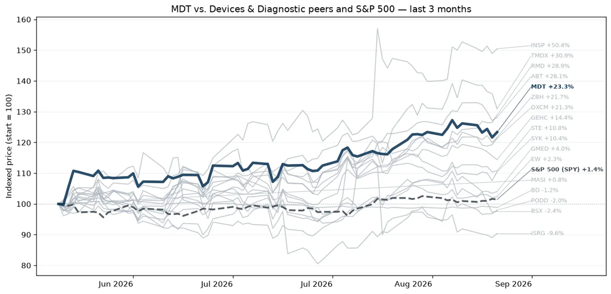

One of the largest medical-device companies, Medtronic develops and manufactures therapeutic medical devices for chronic diseases. Its portfolio includes pacemakers, defibrillators, transcatheter heart valves, stents, spinal fixation devices, neurovascular products, advanced energy, ablation laser therapy, and surgical tools. The company primarily markets its products to healthcare institutions and physicians in the United States, Western Europe, and Japan. Foreign sales account for roughly 50% of the company's total sales.

### Boston Scientific (BSX)

*Devices & Diagnostic · $71.1B · 3m -3.0% · 12m -55.6% · 24m -42.7%*

[Google Finance](https://www.google.com/finance/quote/BSX:NYSE?tab=earnings&hl=en)

Growth-focused medtech leader specializing in minimally invasive cardiovascular, electrophysiology, endoscopy, and neuromodulation devices.

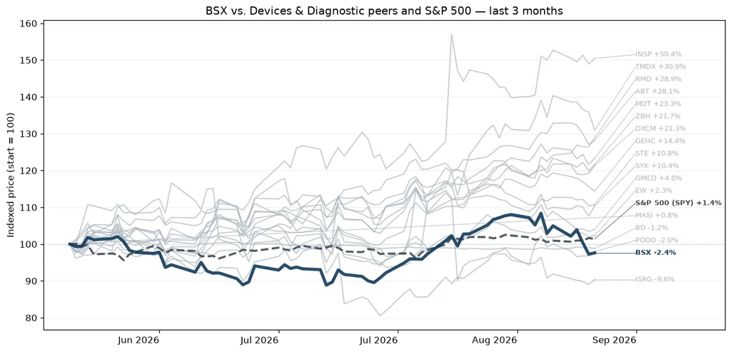

Boston Scientific focuses on less invasive medical devices that are inserted into the human body through small openings or cuts. It manufactures products for use in angioplasty, blood clot filtration, kidney stone management, cardiac rhythm management, catheter-directed ultrasound imaging, upper gastrointestinal tract diagnostics, interventional oncology, neuromodulation for chronic pain, and treatment of incontinence. The firm markets its devices to healthcare professionals and institutions globally. Foreign sales account for roughly 36% of the firm's total sales.

### Stryker (SYK)

*Devices & Diagnostic · $128.9B · 3m +8.4% · 12m -15.5% · 24m -8.2%*

[Google Finance](https://www.google.com/finance/quote/SYK:NYSE?tab=earnings&hl=en)

Premier orthopedic and surgical technology company best known for joint replacements, MedSurg equipment, and Mako robotic assisted surgery systems.

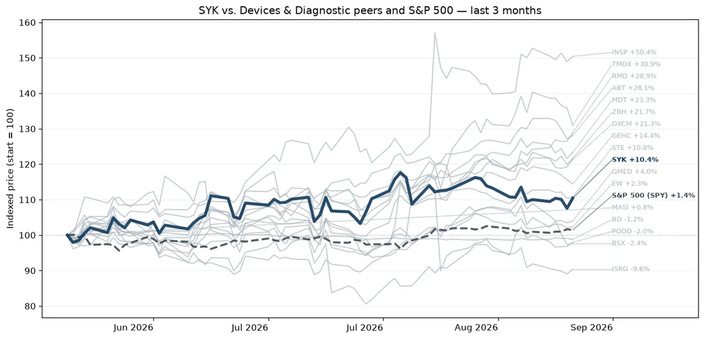

Stryker designs, manufactures, and markets an array of medical equipment, instruments, consumable supplies, and implantable devices. The product portfolio includes hip and knee replacements, extremities, endoscopy systems, operating room equipment, embolic coils, mechanical thrombectomy systems, hospital beds and gurneys, and orthopedic robotics. Stryker remains one of the three largest competitors in reconstructive orthopedic implants and holds the leadership position in operating room equipment. Roughly one-fourth of Stryker's total revenue currently comes from outside the United States.

### Zimmer Biomet (ZBH)

*Devices & Diagnostic · $18.5B · 3m +22.6% · 12m -4.9% · 24m -12.6%*

[Google Finance](https://www.google.com/finance/quote/ZBH:NYSE?tab=earnings&hl=en)

Orthopedic specialist centered on knee, hip, and extremity implants, with robotic surgery offerings for joint reconstruction.

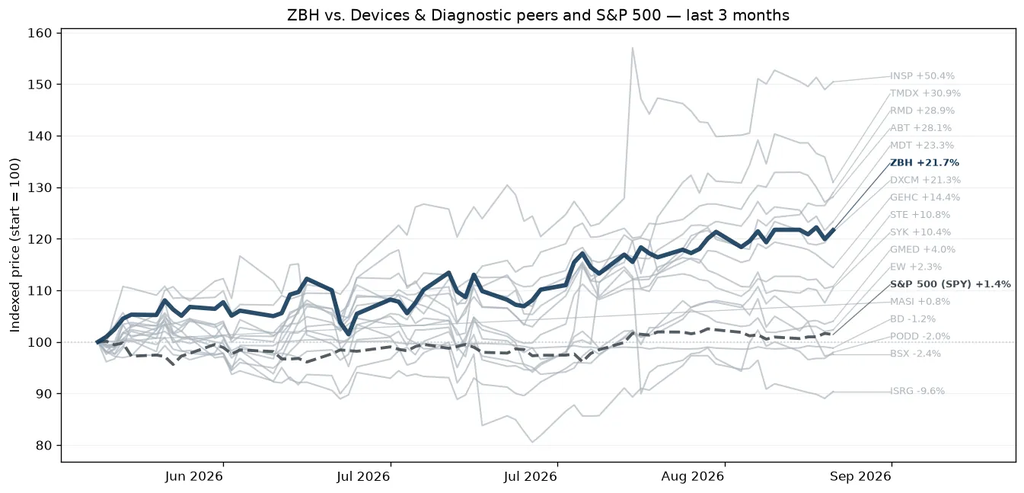

Zimmer Biomet designs, manufactures, and markets orthopedic reconstructive implants as well as supplies and surgical equipment for orthopedic surgery. With the acquisitions of Centerpulse in 2003 and Biomet in 2015, Zimmer holds the leading share of the reconstructive market in the United States, Europe, and Japan. Roughly two-thirds of total revenue is derived from sales of large joints; another fourth comes from extremities, trauma, sports medicine, and related surgical products. The firm spun out its dental and spine businesses in 2022.

### Abbott (ABT)

*Devices & Diagnostic · $182.5B · 3m +31.4% · 12m -15.2% · 24m -0.7%*

[Google Finance](https://www.google.com/finance/quote/ABT:NYSE?tab=earnings&hl=en)

Diversified healthcare company spanning diagnostics, medical devices, nutrition products, and established pharmaceuticals.

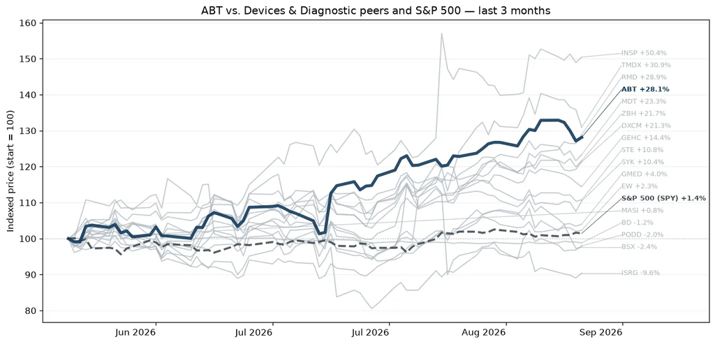

Abbott manufactures and markets cardiovascular and diabetes devices, adult and pediatric nutritional products, diagnostic equipment and testing kits, and branded generic drugs. Products include pacemakers, implantable cardioverter defibrillators, neuromodulation devices, coronary stents, catheters, infant formula, nutritional liquids for adults, continuous glucose monitors, and immunoassays and point-of-care diagnostic equipment. Abbott derives roughly 60% of sales outside the United States.

### Becton Dickinson (BD)

*Devices & Diagnostic · n/a · 3m n/a · 12m n/a · 24m n/a*

[Google Finance](https://www.google.com/finance/quote/BD:NYSEARCA?tab=earnings&hl=en)

leading medical product and component company.

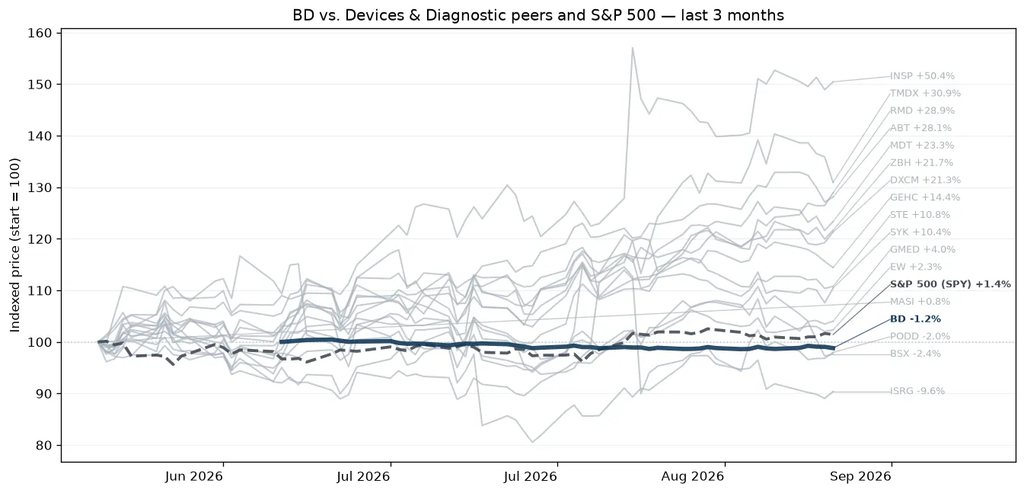

### Edwards LifeSciences (EW)

*Devices & Diagnostic · $51.6B · 3m +4.3% · 12m +10.9% · 24m +28.9%*

[Google Finance](https://www.google.com/finance/quote/EW:NYSE?tab=earnings&hl=en)

Cardiovascular company focused on structural heart therapies, particularly transcatheter and surgical heart valve tech.

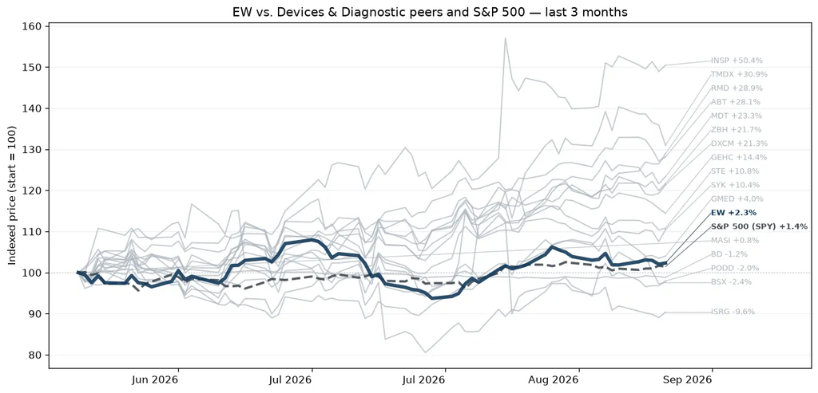

Spun off from Baxter International in 2000, Edwards Lifesciences designs, manufactures, and markets a range of medical devices and equipment for advanced stages of structural heart disease. It has established itself as a leader across key products, including surgical tissue heart valves, transcatheter aortic valves, and transcatheter mitral and tricuspid valve technologies. The firm derives about 60% of its total sales from outside the US.

### Dexcom (DXCM)

*Devices & Diagnostic · $32.8B · 3m +23.2% · 12m +20.5% · 24m +31.0%*

[Google Finance](https://www.google.com/finance/quote/DXCM:NASDAQ?tab=earnings&hl=en)

Leading independent continuous glucose monitoring company.

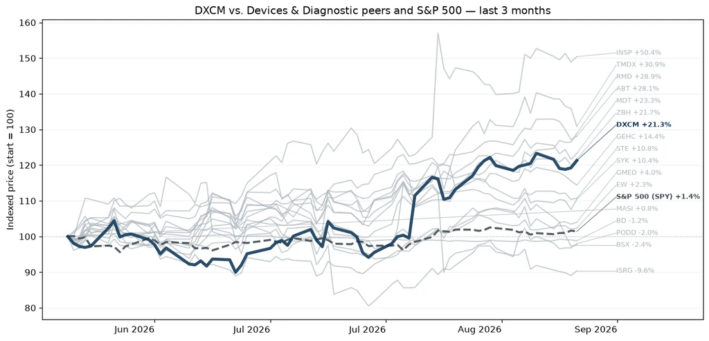

DexCom designs and commercializes continuous glucose monitoring systems for diabetic patients. CGM systems serve as an alternative to the traditional blood glucose meter process, and the company is evolving its CGM systems to provide integration with insulin pumps from Insulet and Tandem for automatic insulin delivery. DexCom's CGMs are available through medical equipment distributors as well as retail pharmacies.

### ResMed (RMD)

*Devices & Diagnostic · $32.4B · 3m +26.1% · 12m -12.5% · 24m -1.9%*

[Google Finance](https://www.google.com/finance/quote/RMD:NYSE?tab=earnings&hl=en)

Sleep and respiratory care known for CPAP devices, masks, and connected software for sleep apnea and respiratory disorders.

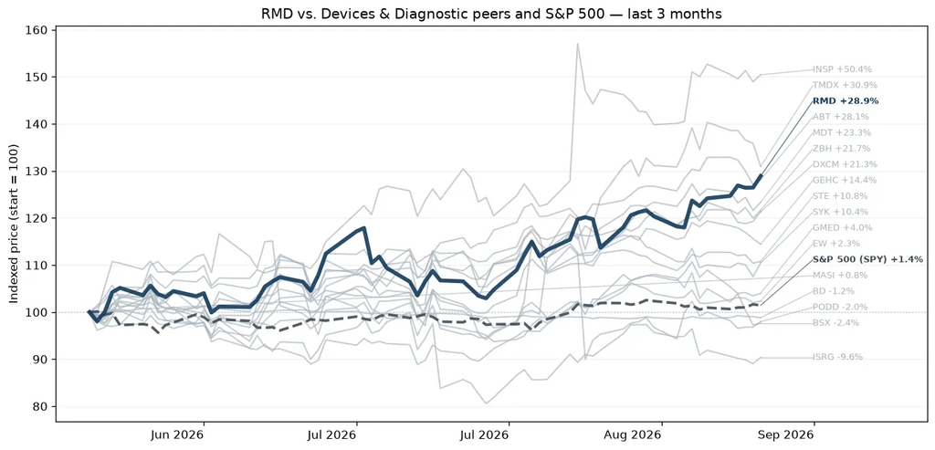

ResMed is one of the largest respiratory care device companies globally, primarily developing and supplying flow generators, masks, and accessories for the treatment of sleep apnea. Increasing diagnosis of sleep apnea combined with aging populations and increasing prevalence of obesity is resulting in a structurally growing market. The company earns roughly two-thirds of its revenue in the Americas and the balance across other regions dominated by Europe, Japan, and Australia. Recent developments and acquisitions have focused on digital health as ResMed is aiming to differentiate itself through the provision of clinical data for use by the patient, medical care advisor, and payer in the out-of-hospital setting.

### Insulet (PODD)

*Devices & Diagnostic · $11.6B · 3m +0.1% · 12m -57.3% · 24m -28.4%*

[Google Finance](https://www.google.com/finance/quote/PODD:NASDAQ?tab=earnings&hl=en)

Diabetes technology company whose Omnipod platform pioneered the tubeless wearable insulin pump market.

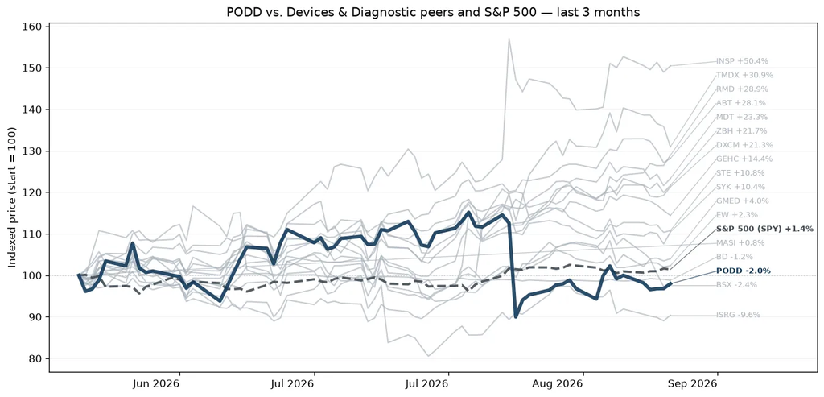

Insulet was founded in 2000 with the goal of making continuous subcutaneous insulin infusion therapy for diabetes easier to use. The result was the Omnipod system, which consists of a small disposable insulin infusion device that can be operated through a smartphone to control dosage. Since the Omnipod was approved by the US Food and Drug Administration in 2005, more than 600,000 insulin-dependent diabetic patients are using it worldwide.

### Globus Medical (GMED)

*Devices & Diagnostic · $11.1B · 3m +1.3% · 12m +35.4% · 24m +14.1%*

[Google Finance](https://www.google.com/finance/quote/GMED:NYSE?tab=earnings&hl=en)

Musculoskeletal device company focused on spine surgery, orthopedic trauma, and robotic navigation techniques.

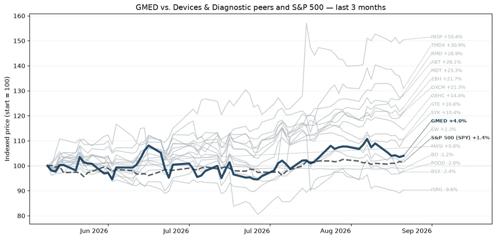

Globus Medical Inc is a medical device company that develops and provides healthcare products and solutions to hospitals, physicians, and surgical centers. The firm's products are organized into two categories: musculoskeletal solutions, which include medical devices and instruments used mostly for spinal and orthopedic procedures, and enabling technologies, which include computer systems developed for enhancing surgical capabilities. The vast majority of the company's revenue is generated from musculoskeletal solutions products, and more than half of the revenue is earned in the United States. It also has its presence internationally.

### Intuitive Surgical (ISRG)

*Devices & Diagnostic · $130.1B · 3m -12.3% · 12m -21.3% · 24m -24.4%*

[Google Finance](https://www.google.com/finance/quote/ISRG:NASDAQ?tab=earnings&hl=en)

Dominant robotic surgery company whose da Vinci systems have come the standard platform for many minimally invasive surgeries.

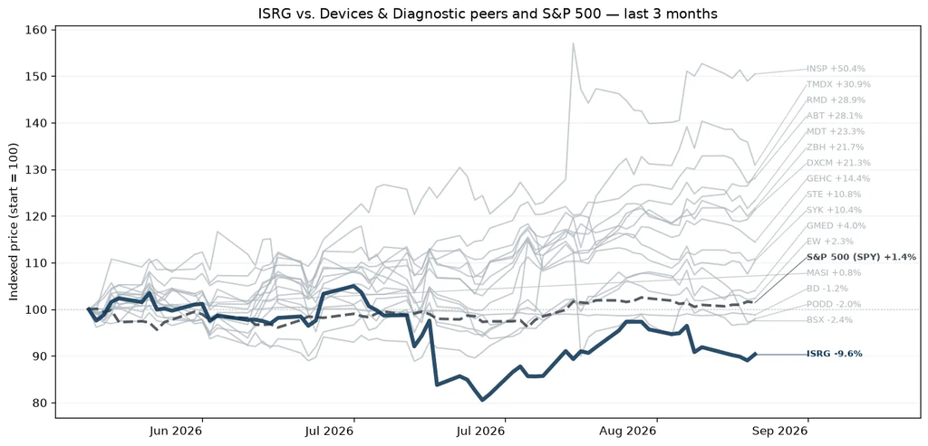

Intuitive develops, produces, and markets a robotic system for assisting minimally invasive surgery. It also provides the instrumentation, disposable accessories, and warranty services for the system. The company has placed more than 10,000 da Vinci systems in hospitals worldwide, with more than 6,000 installations in the US and a growing number in emerging markets.

### GE Healthcare (GEHC)

*Devices & Diagnostic · $31.7B · 3m +15.1% · 12m -2.7% · 24m -15.4%*

[Google Finance](https://www.google.com/finance/quote/GEHC:NASDAQ?tab=earnings&hl=en)

Medical technology & diagnostic company focused on imaging equipment, patient monitoring, ultrasound, and healthcare IT infrastructure.

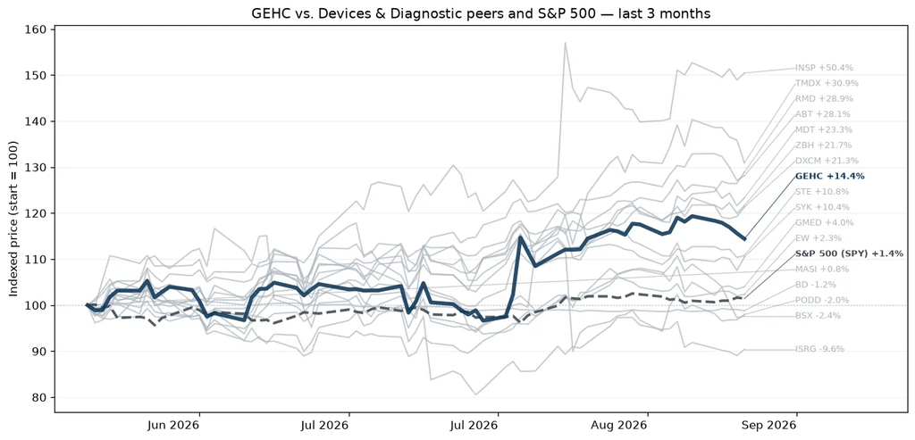

GE HealthCare Technologies is a leading medical technology firm with leading market share in imaging and ultrasound equipment. The company reports four major segments: imaging (45% of revenue), advanced visualization solutions (26%), patient care solutions (15%), and pharmaceutical diagnostics (14%). The company's sales are geographically diverse, with the United States, EMEA, China, and the rest of the world accounting for 46%, 26%, 11%, and 17%, respectively. We estimate approximately half of its revenue is recurring, which consists of servicing (about one-third of revenue), pharmaceutical diagnostics (about 10%-15%), and digital solutions (just over 5%).

### Transmedics (TMDX)

*Devices & Diagnostic · $2.8B · 3m +31.6% · 12m -23.1% · 24m -47.4%*

[Google Finance](https://www.google.com/finance/quote/TMDX:NASDAQ?tab=earnings&hl=en)

Transplant technology and transportation company whose Organ Care System keeps donor organs functioning outside the body, expanding organ supply.

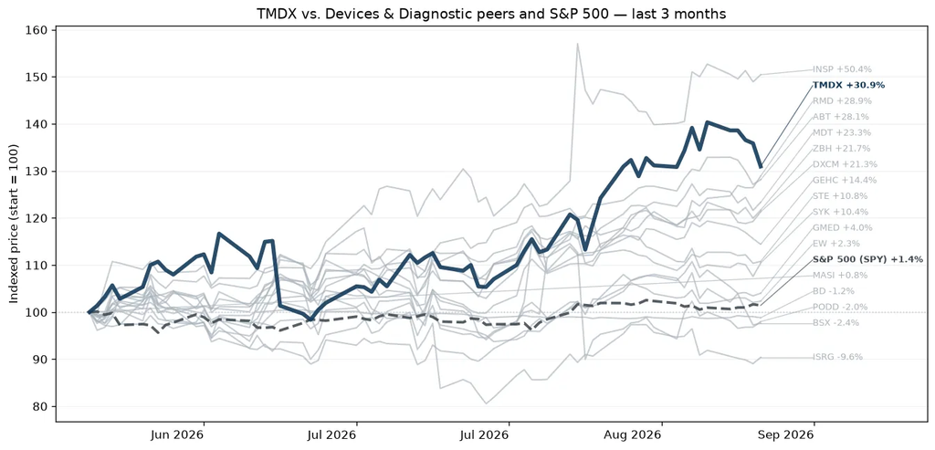

TransMedics Group Inc is a commercial-stage medical technology company transforming organ transplant therapy for end-stage organ failure patients across multiple disease states. It has developed the Organ Care System (OCS) to comprehensively address the limitations of cold storage. The OCS is a portable organ perfusion, optimization, and monitoring system that utilizes technology to replicate near-physiologic conditions for donor organs outside of the human body. The company has developed and is commercializing a proprietary system to preserve and deliver human organs for transplant in a near-physiologic condition to address the limitations of cold storage organ preservation.

### STERIS (STE)

*Devices & Diagnostic · $22.7B · 3m +9.9% · 12m -4.6% · 24m -3.0%*

[Google Finance](https://www.google.com/finance/quote/STE:NYSE?tab=earnings&hl=en)

provider of infection prevention, sterilization, and surgical support products and services.

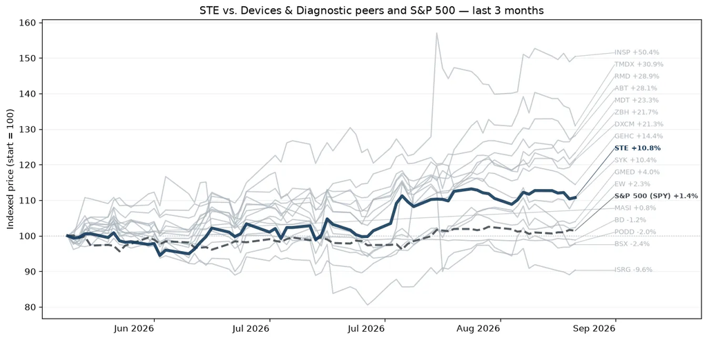

Steris is an Ireland-domiciled medical technology company focused on sterilization services and infection prevention. The company is the global leader in contract sterilization services, ensuring the safe delivery of single-use and implantable medical equipment to hospitals around the world. Steris also sells sterilizers, washer-disinfectors, and other decontamination equipment and supplies for use by care provider facilities and in biopharma manufacturing sites. Domiciled in the United States before its inversion to Ireland, the firm derives approximately 70% of its revenue from Healthcare Services, 20% from Applied Sterilization Technologies, or AST, and 10% from life sciences services after the divestment of its dental products business.

### Masimo (MASI)

*Devices & Diagnostic · n/a · 3m +0.8% · 12m +28.8% · 24m +53.1%*

[Google Finance](https://www.google.com/finance/quote/MASI:NYSE?tab=earnings&hl=en)

provider of patient-monitoring and pulse-oximetry technologies.

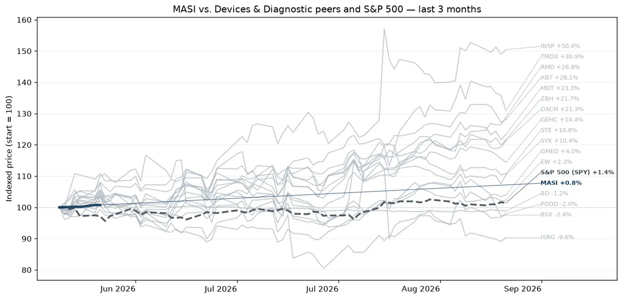

### Inspire Medical Systems (INSP)

*Devices & Diagnostic · $1.9B · 3m +48.5% · 12m -34.4% · 24m -65.8%*

[Google Finance](https://www.google.com/finance/quote/INSP:NYSE?tab=earnings&hl=en)

developer of implantable neurostimulation devices for obstructive sleep apnea.

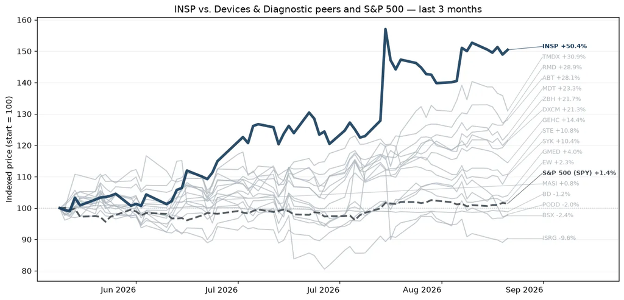

Inspire Medical Systems Inc operates as a medical technology company. It focuses on the development and commercialization of minimally invasive solutions for patients with obstructive sleep apnea (OSA). It offers Inspire system, a neurostimulation technology that provides a safe and effective treatment for moderate to severe obstructive sleep apnea. The firm has operating footprints in the United States and All other countries wherein, it generates a majority of its revenue from the United States. Its segment revenues are derived from the sales of its product, the Inspire system, to hospitals and ambulatory surgery centers in the U.S. and in selected countries in Europe and the Asia Pacific region.

### Eli Lilly (LLY)

*Big Pharma · $1.0T · 3m +6.3% · 12m +60.3% · 24m +22.4%*

[Google Finance](https://www.google.com/finance/quote/LLY:NYSE?tab=earnings&hl=en)

Obesity and diabetes powerhouse with GLP-1 franchise (Zepbound/Mounjaro) fueling growth.

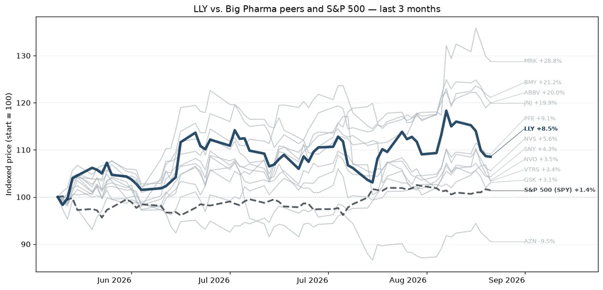

Eli Lilly is a drug firm with a focus on neuroscience, cardiometabolic, cancer, and immunology. Lilly's key products include Verzenio and Jaypirca for cancer; Mounjaro, Zepbound, Foundayo, Jardiance, Trulicity, Humalog, and Humulin for cardiometabolic; and Taltz and Olumiant for immunology.

### Novo Nordisk (NVO)

*Big Pharma · $195.8B · 3m +0.1% · 12m -19.2% · 24m -67.2%*

[Google Finance](https://www.google.com/finance/quote/NVO:NYSE?tab=earnings&hl=en)

Primary GLP-1 competitor to Lilly.

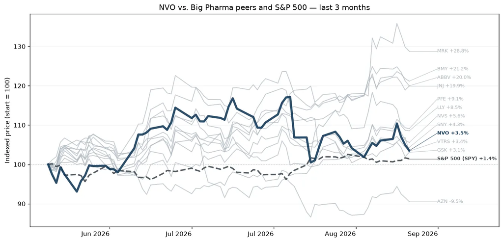

With roughly one-third of the global branded diabetes treatment market, Novo Nordisk is the leading provider of diabetes care products in the world. Based in Denmark, the company manufactures and markets a variety of human and modern insulins, injectable diabetes treatments such as GLP-1 therapy, oral antidiabetic agents, and obesity treatments. Novo also has a biopharmaceutical segment (contributing less than 10% of revenue) that specializes in protein therapies for hemophilia and other disorders.

### AbbVie (ABBV)

*Big Pharma · $430.8B · 3m +17.3% · 12m +21.4% · 24m +30.1%*

[Google Finance](https://www.google.com/finance/quote/ABBV:NYSE?tab=earnings&hl=en)

Immunology and aesthetics leader built around drugs like Skyrizi, Rinvoq, and Botox.

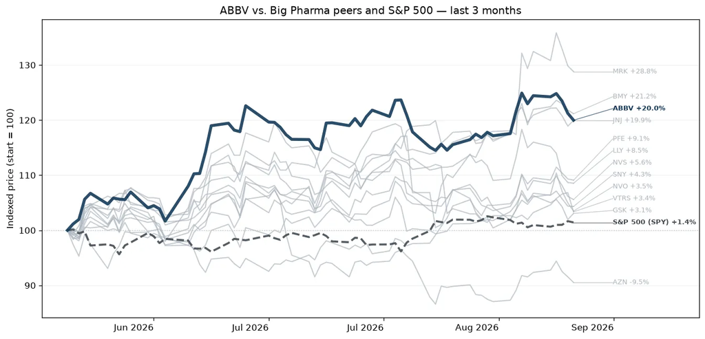

AbbVie is a pharmaceutical firm with a strong exposure to immunology (with Humira, Skyrizi, and Rinvoq) and oncology (with Imbruvica and Venclexta). The company was spun off from Abbott in early 2013. The 2020 acquisition of Allergan added several new products and drugs in aesthetics, including Botox. The 2024 acquisitions of Cerevel (neuroscience) and ImmunoGen (oncology) help supplement AbbVie's portfolio.

### Johnson & Johnson (JNJ)

*Big Pharma · $614.4B · 3m +19.0% · 12m +51.3% · 24m +61.6%*

[Google Finance](https://www.google.com/finance/quote/JNJ:NYSE?tab=earnings&hl=en)

Diversified healthcare giant, combining pharmaceuticals with medical devices.

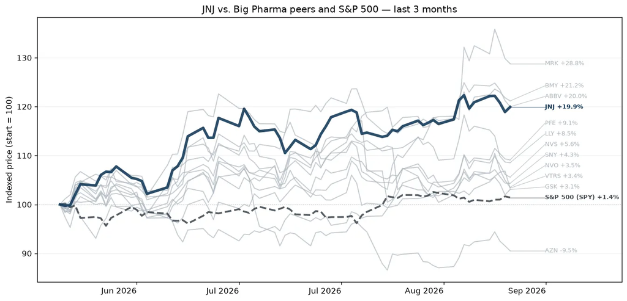

Johnson & Johnson is the world's largest and most diverse healthcare firm. It has two divisions: innovative medicine and medtech. These now represent all of the company's sales following the divestment of the consumer business, Kenvue, in 2023. After restructurings in 2023-24, the drug division focuses on three main therapeutic areas: immunology, oncology, and neurology. Geographically, just over half of total revenue is generated in the United States.

### Pfizer (PFE)

*Big Pharma · $144.8B · 3m +6.8% · 12m +12.9% · 24m -3.6%*

[Google Finance](https://www.google.com/finance/quote/PFE:NYSE?tab=earnings&hl=en)

Global pharma company known for vaccines and oncology.

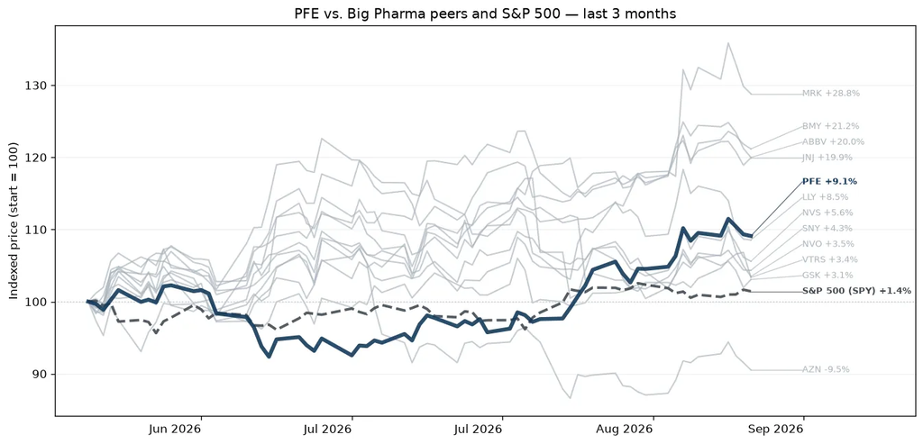

Pfizer is one of the world's largest pharmaceutical firms, with annual sales of roughly $60 billion. While it historically sold many types of healthcare products and chemicals, now prescription drugs and vaccines account for the majority of sales. Top sellers include pneumococcal vaccine Prevnar 13 and cardiology drugs Vyndaqel and Eliquis. Pfizer sells these products globally, with international sales representing 40% of total sales. Within international sales, emerging markets are a major contributor.

### Merck (MRK)

*Big Pharma · $316.1B · 3m +25.0% · 12m +76.4% · 24m +25.2%*

[Google Finance](https://www.google.com/finance/quote/MRK:NYSE?tab=earnings&hl=en)

Pharma leader driven by Keytruda, one of the world's most important cancer drugs.

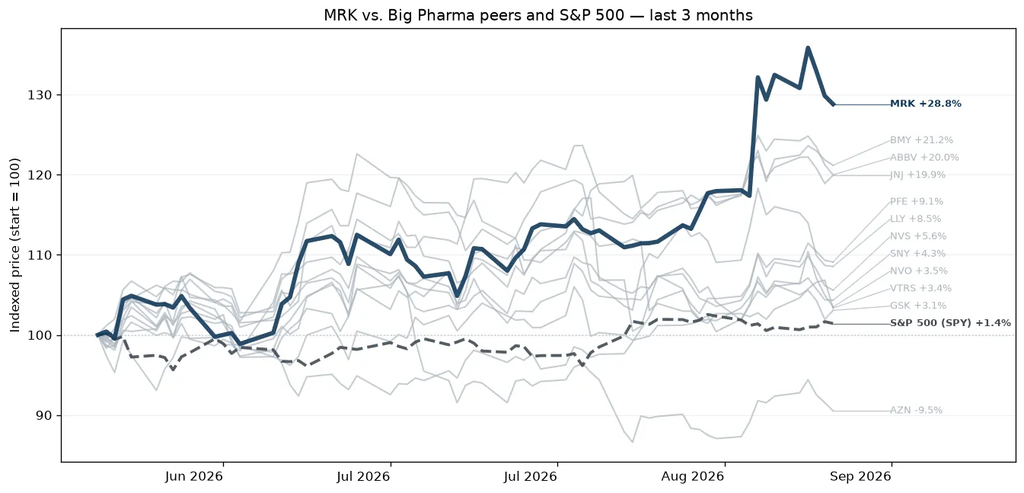

Merck makes pharmaceutical products to treat several conditions in a number of therapeutic areas, including cardiometabolic disease, cancer, and infections. Within cancer, the firm's immuno-oncology platform, led by Keytruda, is a major contributor to overall sales. The company also has a substantial vaccine business aimed at preventing pediatric diseases, as well as Gardasil for human papillomavirus. Additionally, Merck sells animal health-related drugs. From a geographical perspective, 47% of the company's sales are generated from US human health (pharmaceuticals and vaccines).

### Bristol Myers Squibb (BMY)

*Big Pharma · $134.6B · 3m +16.4% · 12m +41.1% · 24m +33.3%*

[Google Finance](https://www.google.com/finance/quote/BMY:NYSE?tab=earnings&hl=en)

Oncology and immunology specialist with a porfolio centered on cancer and cardiovascular medicines.

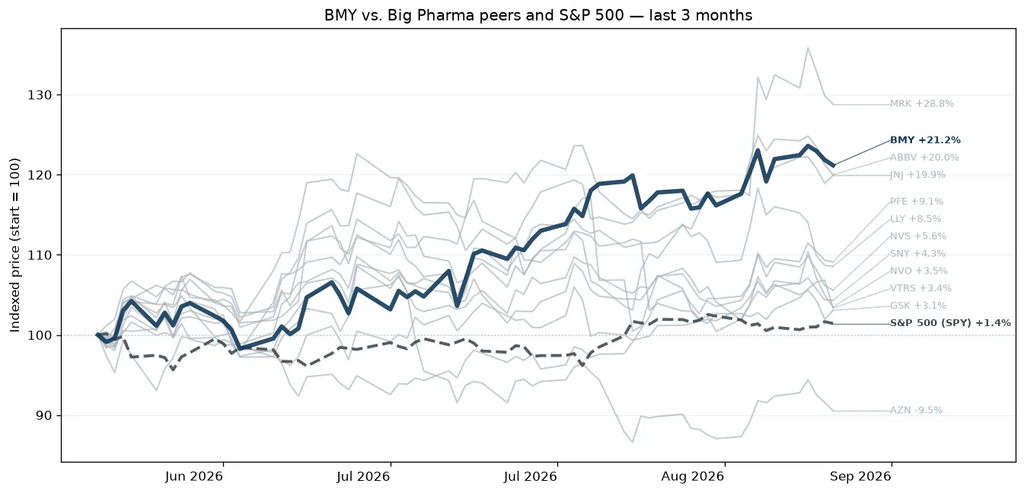

Bristol Myers Squibb discovers, develops, and markets drugs for various therapeutic areas, such as cardiovascular, cancer, and immune disorders. A key focus for Bristol is immuno-oncology, where the firm is a leader in drug development. Bristol derives close to 70% of total sales from the US, showing a higher dependence on the US market than most of its peer group.

### Viatris (VTRS)

*Big Pharma · $20.6B · 3m +0.5% · 12m +54.9% · 24m +35.3%*

[Google Finance](https://www.google.com/finance/quote/VTRS:NASDAQ?tab=earnings&hl=en)

Global generic and off-patent medicine company focused on scale manufacturing and cash generation, rather than breakthrough innovation.

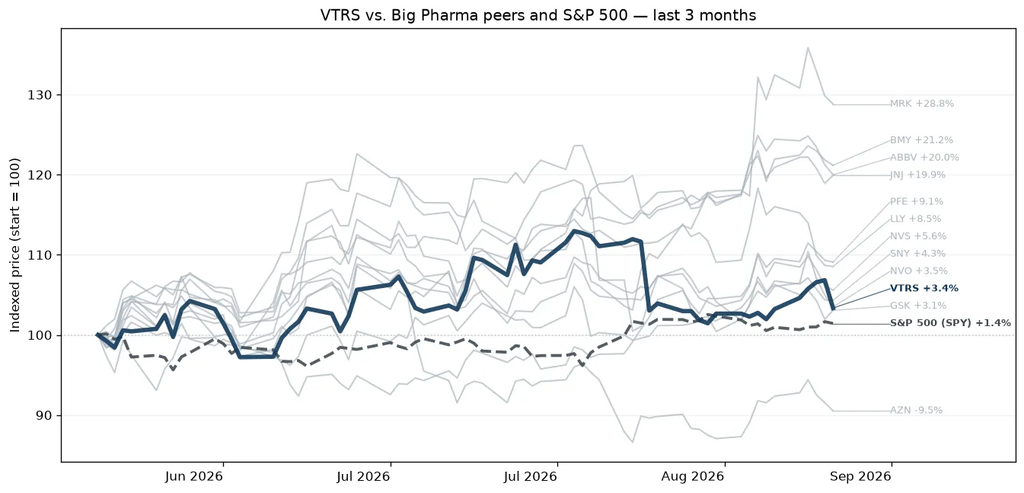

Viatris was formed in November 2020 through the combination of Upjohn, a wholly owned subsidiary of Pfizer that specialized in off-patent drugs, and Mylan, a global pharmaceutical manufacturer that focused on generic and specialty drugs. By joining forces, Viatris became one of the largest generic drug manufacturers in the world, servicing over 165 countries. Generics (commoditized and complex) and biosimilars make up roughly 40% of Viatris' total sales. The remaining 60% of sales are derived from its portfolio of legacy products, which includes Lipitor, Norvasc, Lyrica, and Viagra. While it covers more than 10 major therapeutic areas, Viatris has identified dermatology, ophthalmology, and gastroenterology as its three key areas of focus for future innovations.

### AstraZeneca (AZN)

*Big Pharma · $241.3B · 3m -12.4% · 12m +1.8% · 24m -7.2%*

[Google Finance](https://www.google.com/finance/quote/AZN:NYSE?tab=earnings&hl=en)

global pharmaceutical company with leading oncology, cardiovascular, and rare disease franchises.

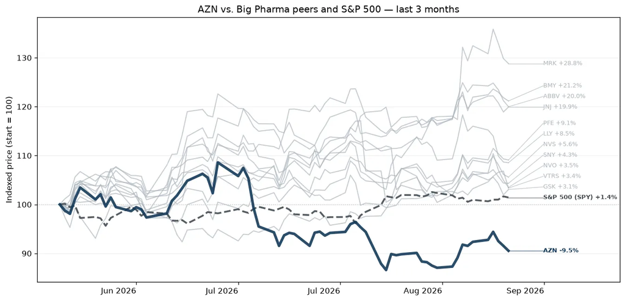

A merger between Astra of Sweden and Zeneca of the United Kingdom formed AstraZeneca in 1999. The firm sells branded drugs across a number of major therapeutic areas, including oncology (over 40% of total revenue), cardiovascular, renal, and metabolic (over 20%), rare disease (16%), and respiratory and immunology (15%). The majority of sales comes from international markets, with the United States representing close to one-third of its sales.

### Novartis (NVS)

*Big Pharma · $291.3B · 3m +2.4% · 12m +21.5% · 24m +27.2%*

[Google Finance](https://www.google.com/finance/quote/NVS:NYSE?tab=earnings&hl=en)

innovative pharmaceutical company focused on cardiovascular, immunology, neuroscience, and oncology therapies.

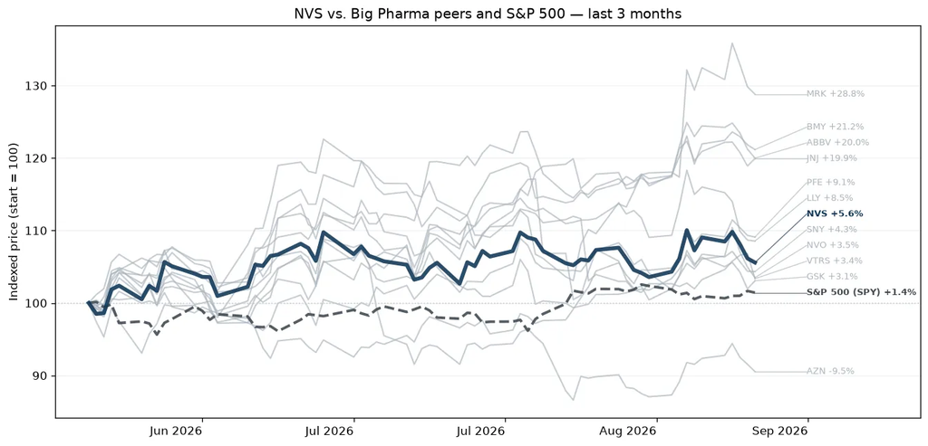

Novartis develops and manufactures innovative drugs. Key areas of drug development are oncology, immunology, neuroscience, respiratory, and cardiovascular, renal, and metabolic. It also has an established medicines business, which includes off-patent franchises. The company sells its products globally, with the United States constituting close to one-third of total revenue.

### Sanofi (SNY)

*Big Pharma · $103.6B · 3m +2.6% · 12m -9.4% · 24m -20.3%*

[Google Finance](https://www.google.com/finance/quote/SNY:NASDAQ?tab=earnings&hl=en)

diversified pharmaceutical company with strengths in vaccines, immunology, and rare diseases.

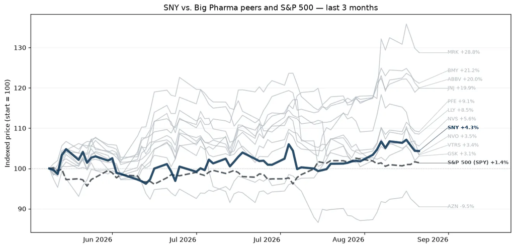

Sanofi develops and markets drugs with a concentration in immunology, vaccines, and rare diseases. Although the company offers a diverse array of drugs, its highest-revenue product, Dupixent, accounts for over 30% of total sales. Profits for this immunology blockbuster drug are shared with Regeneron. About 45% of total revenue comes from the United States, 20% from Europe, and 6% from China.